# Project: Movies Data Analysis

- Introduction
- Data Wrangling
- Exploratory Data Analysis
- Conclusions

## Introduction

The Movies dataset is provided in the project and we need to derive some insights. These insights must be as accurate as possible and must fulfill the purpose. The analysis must justify the questions framed below and must be conclusive to ceratin extent.The Movies business is a well established business and deriving some valuable insights from the dataset may result into good decision making based on the conclusion of the analysis.

We are going to answer the following questions in the dataset :

1] Is the Profit impacted by the Movie Revenue,Vote rating or Release year ?

2] Which cast are considered to be most profitable cast ?

3] Which ones are the top 10 profitable movies?

4] The variation in the number of movies produced with respect to the years?

5] Which movie genre is most profitable?

6] What is average runtime of various genre movies ?

### Imports required to get the insights

```python
import pandas as pd
import matplotlib.pyplot as plt
import numpy as np
import seaborn as sns

#This setting is for the values that are displayed as scientific notations
pd.set_option('display.float_format', lambda x: f'{x:,.3f}')
%matplotlib inline
```

## Data Wrangling

In this section we would :

1] Collect the data

2] Inspect the data

3] Derive the changes to be made

4] Clean up the data

### Collect the data

```python
df = pd.read_csv('movies.csv')
df.head(1)
```

|  | id | imdb_id | popularity | budget | revenue | original_title | cast | homepage | director | tagline | ... | overview | runtime | genres | production_companies | release_date | vote_count | vote_average | release_year | budget_adj | revenue_adj |
| --- | --- | --- | --- | --- | --- | --- | --- | --- | --- | --- | --- | --- | --- | --- | --- | --- | --- | --- | --- | --- | --- |
| 0 | 135397 | tt0369610 | 32.986 | 150000000 | 1513528810 | Jurassic World | Chris Pratt\|Bryce Dallas Howard\|Irrfan Khan\|Vi... | http://www.jurassicworld.com/ | Colin Trevorrow | The park is open. | ... | Twenty-two years after the events of Jurassic ... | 124 | Action\|Adventure\|Science Fiction\|Thriller | Universal Studios\|Amblin Entertainment\|Legenda... | 06-09-2015 | 5562 | 6.500 | 2015 | 137,999,939.300 | 1,392,445,893.000 |

1 rows × 21 columns

### Inspect the data

```python
df.shape
```

```
(10866, 21)
```

```python
df.info()
```

```
<class 'pandas.core.frame.DataFrame'>
RangeIndex: 10866 entries, 0 to 10865
Data columns (total 21 columns):
 #   Column                Non-Null Count  Dtype
---  ------                --------------  -----
 0   id                    10866 non-null  int64
 1   imdb_id               10856 non-null  object
 2   popularity            10866 non-null  float64
 3   budget                10866 non-null  int64
 4   revenue               10866 non-null  int64
 5   original_title        10866 non-null  object
 6   cast                  10790 non-null  object
 7   homepage              2936 non-null   object
 8   director              10822 non-null  object
 9   tagline               8042 non-null   object
 10  keywords              9373 non-null   object
 11  overview              10862 non-null  object
 12  runtime               10866 non-null  int64
 13  genres                10843 non-null  object
 14  production_companies  9836 non-null   object
 15  release_date          10866 non-null  object
 16  vote_count            10866 non-null  int64
 17  vote_average          10866 non-null  float64
 18  release_year          10866 non-null  int64
 19  budget_adj            10866 non-null  float64
 20  revenue_adj           10866 non-null  float64
dtypes: float64(4), int64(6), object(11)
memory usage: 1.3+ MB
```

```python
df.describe()
```

|  | id | popularity | budget | revenue | runtime | vote_count | vote_average | release_year | budget_adj | revenue_adj |
| --- | --- | --- | --- | --- | --- | --- | --- | --- | --- | --- |
| count | 10,866.000 | 10,866.000 | 10,866.000 | 10,866.000 | 10,866.000 | 10,866.000 | 10,866.000 | 10,866.000 | 10,866.000 | 10,866.000 |
| mean | 66,064.177 | 0.646 | 14,625,701.094 | 39,823,319.793 | 102.071 | 217.390 | 5.975 | 2,001.323 | 17,551,039.823 | 51,364,363.253 |
| std | 92,130.137 | 1.000 | 30,913,213.831 | 117,003,486.582 | 31.381 | 575.619 | 0.935 | 12.813 | 34,306,155.723 | 144,632,485.038 |
| min | 5.000 | 0.000 | 0.000 | 0.000 | 0.000 | 10.000 | 1.500 | 1,960.000 | 0.000 | 0.000 |
| 25% | 10,596.250 | 0.208 | 0.000 | 0.000 | 90.000 | 17.000 | 5.400 | 1,995.000 | 0.000 | 0.000 |
| 50% | 20,669.000 | 0.384 | 0.000 | 0.000 | 99.000 | 38.000 | 6.000 | 2,006.000 | 0.000 | 0.000 |
| 75% | 75,610.000 | 0.714 | 15,000,000.000 | 24,000,000.000 | 111.000 | 145.750 | 6.600 | 2,011.000 | 20,853,251.080 | 33,697,095.718 |
| max | 417,859.000 | 32.986 | 425,000,000.000 | 2,781,505,847.000 | 900.000 | 9,767.000 | 9.200 | 2,015.000 | 425,000,000.000 | 2,827,123,750.000 |

### Derive the change to be made

The things that we notice are :

1] There are many columns that are not relevant to our questions and hence, they wont be playing any role in our insights calculations.

Solution : We can delete the columns that are not important to our insights.

2] There are many columns in the budget and the revenue section that have 0 value.This is critical as we wont actually know the budget of the movie or the total revenue earned by the movie.The profit trend calculated on the basis of these 0' values would lead to wrong insights and may deviate the trends.

Solution : Dropping the rows where the budget or revenue is 0 is the only solution in order to avoid wrong calculations.

3] There are null values encountered in production companies column.

Solution : We could think of filling the mean values in the vacant place but the production companies cannot be filled with any values randomly as it may affect our calculations.We would drop these rows as there are no significant amount of rows wit null calues.

4] The data must also be inspected for duplicates if any.

Solution : There are hardly any duplicates in the data

### Dropping the columns that are not important.

```python
df.drop(['id','imdb_id','homepage','tagline','overview','budget_adj','revenue_adj','release_date','keywords'],inplace=True,axis=1)
```

```python
df.head()
```

|  | popularity | budget | revenue | original_title | cast | director | runtime | genres | production_companies | vote_count | vote_average | release_year |
| --- | --- | --- | --- | --- | --- | --- | --- | --- | --- | --- | --- | --- |
| 0 | 32.986 | 150000000 | 1513528810 | Jurassic World | Chris Pratt\|Bryce Dallas Howard\|Irrfan Khan\|Vi... | Colin Trevorrow | 124 | Action\|Adventure\|Science Fiction\|Thriller | Universal Studios\|Amblin Entertainment\|Legenda... | 5562 | 6.500 | 2015 |
| 1 | 28.420 | 150000000 | 378436354 | Mad Max: Fury Road | Tom Hardy\|Charlize Theron\|Hugh Keays-Byrne\|Nic... | George Miller | 120 | Action\|Adventure\|Science Fiction\|Thriller | Village Roadshow Pictures\|Kennedy Miller Produ... | 6185 | 7.100 | 2015 |
| 2 | 13.113 | 110000000 | 295238201 | Insurgent | Shailene Woodley\|Theo James\|Kate Winslet\|Ansel... | Robert Schwentke | 119 | Adventure\|Science Fiction\|Thriller | Summit Entertainment\|Mandeville Films\|Red Wago... | 2480 | 6.300 | 2015 |
| 3 | 11.173 | 200000000 | 2068178225 | Star Wars: The Force Awakens | Harrison Ford\|Mark Hamill\|Carrie Fisher\|Adam D... | J.J. Abrams | 136 | Action\|Adventure\|Science Fiction\|Fantasy | Lucasfilm\|Truenorth Productions\|Bad Robot | 5292 | 7.500 | 2015 |
| 4 | 9.335 | 190000000 | 1506249360 | Furious 7 | Vin Diesel\|Paul Walker\|Jason Statham\|Michelle ... | James Wan | 137 | Action\|Crime\|Thriller | Universal Pictures\|Original Film\|Media Rights ... | 2947 | 7.300 | 2015 |

### Extracting the rows that have revenue or budget as 0 and dropping them.

```python
df.query('budget==0 or revenue==0').shape
```

```
(7011, 12)
```

```python
df.drop(df.query('budget==0 or revenue==0').index, axis=0, inplace=True)
```

```python
df.shape
```

```
(3855, 12)
```

### Checking for the null occurences and dropping them

```python
df.isnull().sum()
```

```
popularity               0
budget                   0
revenue                  0
original_title           0
cast                     4
director                 1
runtime                  0
genres                   0
production_companies    46
vote_count               0
vote_average             0
release_year             0
dtype: int64
```

```python
df.dropna(inplace=True)
```

```python
df.isnull().sum()
```

```
popularity              0
budget                  0
revenue                 0
original_title          0
cast                    0
director                0
runtime                 0
genres                  0
production_companies    0
vote_count              0
vote_average            0
release_year            0
dtype: int64
```

### Checking for the duplicates and dropping them

```python
df.duplicated().sum()
```

```
1
```

```python
df.drop_duplicates(inplace=True)
```

```python
df.duplicated().sum()
```

```
0
```

### Checking the data types

```python
df.dtypes
```

```
popularity              float64
budget                    int64
revenue                   int64
original_title           object
cast                     object
director                 object
runtime                   int64
genres                   object
production_companies     object
vote_count                int64
vote_average            float64
release_year              int64
dtype: object
```

## Exploratory Data Analysis

### Question 1 : Is the Profit impacted by the Movie Revenue,Vote rating or Release year ?

### Creating a profit column in order to avoid its calculation again and again

```python
df['profit'] = df['revenue'] - df['budget']
```

```python
df.head(1)
```

|  | popularity | budget | revenue | original_title | cast | director | runtime | genres | production_companies | vote_count | vote_average | release_year | profit |
| --- | --- | --- | --- | --- | --- | --- | --- | --- | --- | --- | --- | --- | --- |
| 0 | 32.986 | 150000000 | 1513528810 | Jurassic World | Chris Pratt\|Bryce Dallas Howard\|Irrfan Khan\|Vi... | Colin Trevorrow | 124 | Action\|Adventure\|Science Fiction\|Thriller | Universal Studios\|Amblin Entertainment\|Legenda... | 5562 | 6.500 | 2015 | 1363528810 |

### Plotting a scatter plot which helps us to inspect the relation between 2 attributes or variables.

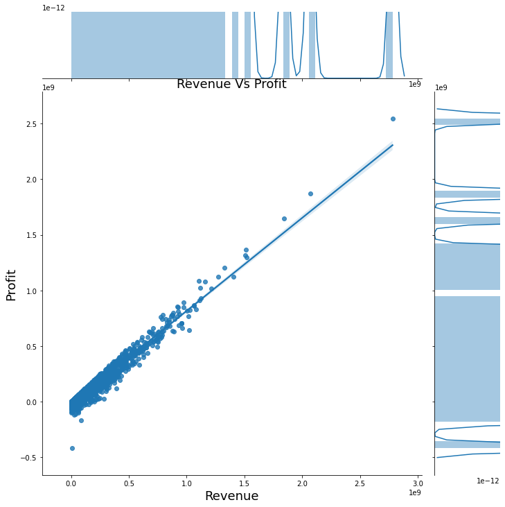

```python
sns.jointplot('revenue','profit',data=df,kind='reg',size=10)
plt.xlabel('Revenue',fontsize=18)
plt.ylabel('Profit', fontsize=18)
plt.title('Revenue Vs Profit', fontsize=18);
```

### As expected, The more the revenue the more the profit. The graph shows positive slope of all the data points plotted.The graph shows direct proportionality between Revenue and Profit

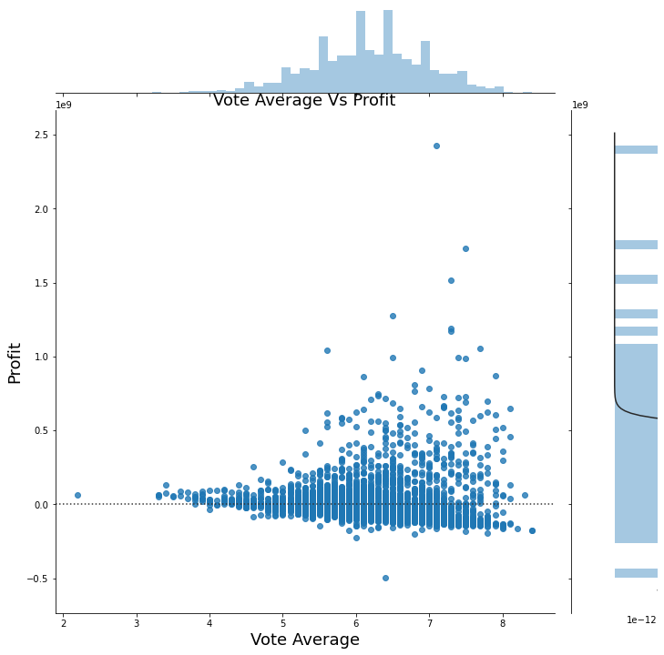

```python
sns.jointplot('vote_average','profit',data=df,kind='resid',size=10)
plt.xlabel('Vote Average',fontsize=18)
plt.ylabel('Profit', fontsize=18)
plt.title('Vote Average Vs Profit', fontsize=18);
```

### We can say the the effect of vote average on the profit is not very important. Only the vote average is not trustworthy to determine the Profit of a particular movie. There is no significant relation between the vote average and the profit.

[figure not shown]

```python
sns.jointplot('release_year','profit',data=df,kind='reg',size=10)
plt.xlabel('Release Year',fontsize=18)
plt.ylabel('Profit', fontsize=18)
plt.title('Vote Average Vs Profit', fontsize=18);
```

### The profit has significantly increased over the years. The movie business has come a long way and has continuously increased over the years.We can say that the relation between the release year and the profit is moderately strong.

### 2] Which cast are considered to be most profitable cast ?

```python
#Create a new dataframe for the cast separation as the data is separated with | character
cast_df = pd.DataFrame()
```

```python
#Copying the cast and the profit column into the new dataframe
cast_df = df[['cast','profit']].copy()
```

```python
from itertools import chain

#Splitting the cast string with the help of pipe character
#cast_split is a list of the cast
cast_split = cast_df['cast'].str.split('|')

#creating the dataframe with the same name with the help of pd.Dataframe
cast_df = pd.DataFrame({

    #Setting the new profit column to the profit of all the cast that have worked in the same movie
    'profit':cast_df['profit'].values.repeat(cast_split.str.len()),

    #Using the chain import to convert the cast names as the rows of the new dataframe
    'cast':list(chain.from_iterable(cast_split.tolist()))
}
)
```

```python
cast_df['profit'][:20]
```

```
0     1363528810
1     1363528810
2     1363528810
3     1363528810
4     1363528810
5      228436354
6      228436354
7      228436354
8      228436354
9      228436354
10     185238201
11     185238201
12     185238201
13     185238201
14     185238201
15    1868178225
16    1868178225
17    1868178225
18    1868178225
19    1868178225
Name: profit, dtype: int64
```

```python
#Creating a new data frame using reset_index for the calculated sum
cast_df = cast_df.groupby('cast')['profit'].sum().reset_index(name='total_profit')
```

```python
#Sorting the dataframe according to the total_profit attribute
cast_df = cast_df.sort_values('total_profit',ascending=False)[:10]
cast_df
```

|  | cast | total_profit |
| --- | --- | --- |
| 2397 | Harrison Ford | 6713284728 |
| 1944 | Emma Watson | 6666245597 |
| 1416 | Daniel Radcliffe | 6511036755 |
| 6354 | Tom Cruise | 6431203020 |
| 5602 | Rupert Grint | 6408638290 |
| 6360 | Tom Hanks | 6322073020 |
| 2527 | Ian McKellen | 6106890840 |
| 5437 | Robert Downey Jr. | 5368997163 |
| 5221 | Ralph Fiennes | 5327798062 |
| 4906 | Orlando Bloom | 5141927828 |

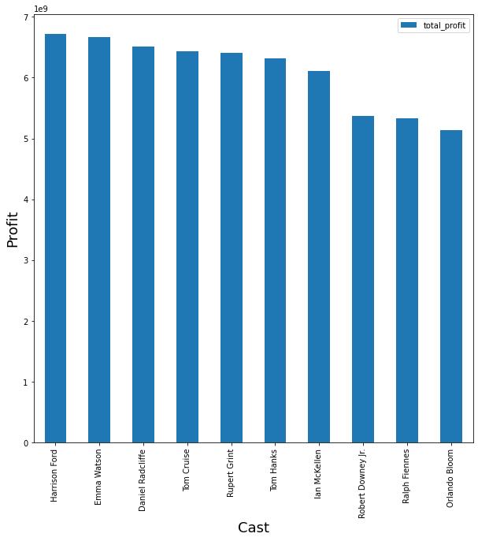

```python
cast_df.plot('cast','total_profit',kind='bar',figsize=(10,10));
plt.xticks(rotation=90)
plt.xlabel('Cast',fontsize=18)
plt.ylabel('Profit',fontsize=18);
```

### The graph shows the top 10 most profitable cast that have earned most profits for the movies.Casting one of these casts would increase the chances of a movie being successful and profitable

### 3] Which ones are the top 10 profitable movies?

```python
df_top = df.sort_values('profit',ascending = False,axis=0)[:10]
```

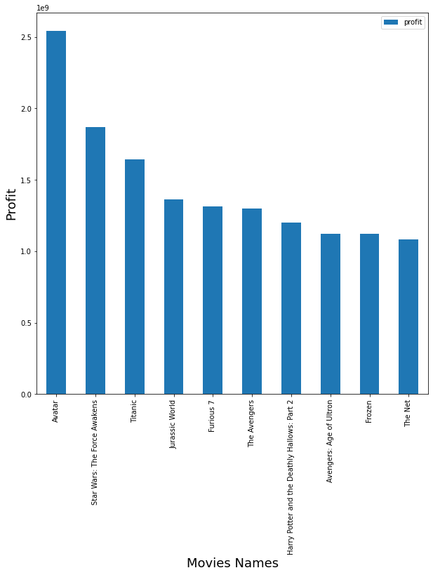

```python
df_top.plot('original_title','profit',kind='bar',figsize=(10,10))
plt.xticks(rotation=90);
plt.xlabel('Movies Names', fontsize=18)
plt.ylabel('Profit',fontsize=18);
```

### The above graph shows the most profitable movies over the years

### 4] The variation in the number of movies produced with respect to the years?

```python
movies_cnt = df.groupby('release_year')['original_title'].count().reset_index(name='count')
```

```python
movies_cnt.head(20)
```

|  | release_year | count |
| --- | --- | --- |
| 0 | 1960 | 5 |
| 1 | 1961 | 10 |
| 2 | 1962 | 7 |
| 3 | 1963 | 6 |
| 4 | 1964 | 7 |
| 5 | 1965 | 5 |
| 6 | 1966 | 5 |
| 7 | 1967 | 13 |
| 8 | 1968 | 9 |
| 9 | 1969 | 4 |
| 10 | 1970 | 11 |
| 11 | 1971 | 13 |
| 12 | 1972 | 8 |
| 13 | 1973 | 12 |
| 14 | 1974 | 13 |
| 15 | 1975 | 9 |
| 16 | 1976 | 15 |
| 17 | 1977 | 19 |
| 18 | 1978 | 17 |
| 19 | 1979 | 16 |

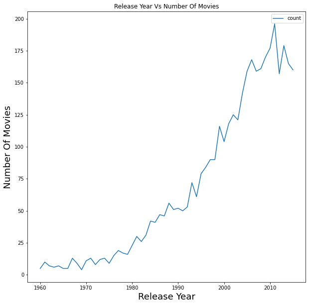

```python
movies_cnt.plot('release_year','count',figsize=(10,10))
plt.xlabel('Release Year', fontsize=18)
plt.ylabel('Number Of Movies',fontsize=18)
plt.title('Release Year Vs Number Of Movies');
```

### The number of movies produced over the years have significantly increased. A highly noticeble trend can be seen from the 2000's.

### 5] Which movie genre is most profitable?

```python
# Creating data with the genres splitted according to the | character and setting the profit as the genre
genre_df = pd.DataFrame(df.genres.str.split('|').tolist(), index=df.profit).stack()
genre_df
```

```
profit
1363528810  0             Action
            1          Adventure
            2    Science Fiction
            3           Thriller
228436354   0             Action
                      ...
8000000     2              Drama
            3                War
            4            Romance
6885000     0          Adventure
            1    Science Fiction
Length: 10180, dtype: object
```

```python
#Creating a dataframe out of the data and altering the index to the standard 0,1...
genre_df = genre_df.reset_index([0,'profit'])
```

```python
genre_df.head()
```

|  | profit | 0 |
| --- | --- | --- |
| 0 | 1363528810 | Action |
| 1 | 1363528810 | Adventure |
| 2 | 1363528810 | Science Fiction |
| 3 | 1363528810 | Thriller |
| 4 | 228436354 | Action |

```python
genre_df.columns=['profit','genre']
```

```python
genre_df.head()
```

|  | profit | genre |
| --- | --- | --- |
| 0 | 1363528810 | Action |
| 1 | 1363528810 | Adventure |
| 2 | 1363528810 | Science Fiction |
| 3 | 1363528810 | Thriller |
| 4 | 228436354 | Action |

```python
#Creating a new data frame having the sum of the total profit grouped by genre
genre_df = genre_df.groupby('genre')['profit'].sum().reset_index(name='total_profit')
```

```python
#Sorting the total_profit values
genre_df = genre_df.sort_values('total_profit',ascending=False)
```

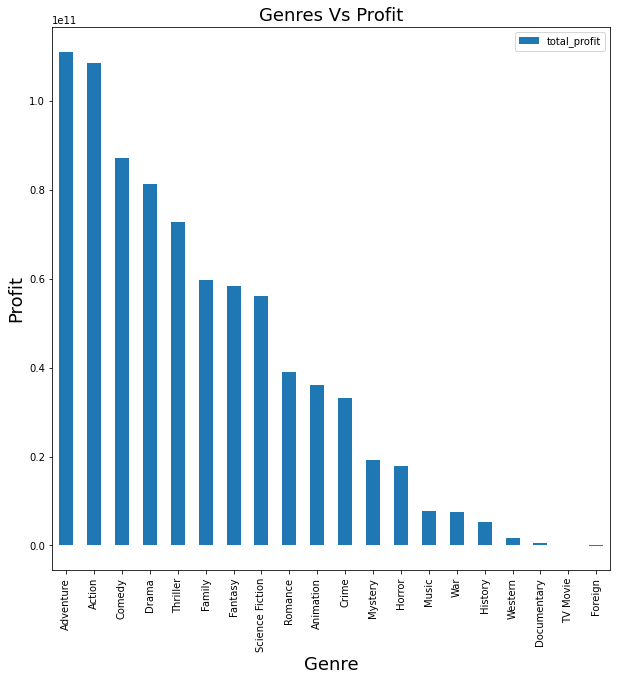

```python
genre_df.plot('genre','total_profit',kind='bar',figsize=(10,10))
plt.xlabel('Genre',fontsize=18)
plt.ylabel('Profit',fontsize=18)
plt.title('Genres Vs Profit',fontsize=18);
```

### The graph shows the most profitable genres ranging from high to low i.e from left to right. This data can be pretty helpful for the upcoming movies and their genre selection

```python
df.head(1)
```

|  | popularity | budget | revenue | original_title | cast | director | runtime | genres | production_companies | vote_count | vote_average | release_year | profit |
| --- | --- | --- | --- | --- | --- | --- | --- | --- | --- | --- | --- | --- | --- |
| 0 | 32.986 | 150000000 | 1513528810 | Jurassic World | Chris Pratt\|Bryce Dallas Howard\|Irrfan Khan\|Vi... | Colin Trevorrow | 124 | Action\|Adventure\|Science Fiction\|Thriller | Universal Studios\|Amblin Entertainment\|Legenda... | 5562 | 6.500 | 2015 | 1363528810 |

### 6] What is average runtime of various genre movies ?

```python
#Creating a new dataframe as we created for the genres
runtime_df = pd.DataFrame(df.genres.str.split('|').tolist(), index=df.runtime).stack()
runtime_df
```

```
runtime
124      0             Action
         1          Adventure
         2    Science Fiction
         3           Thriller
120      0             Action
                   ...
182      2              Drama
         3                War
         4            Romance
100      0          Adventure
         1    Science Fiction
Length: 10180, dtype: object
```

```python
runtime_df = runtime_df.reset_index([0,'runtime'])
```

```python
runtime_df.head()
```

|  | runtime | 0 |
| --- | --- | --- |
| 0 | 124 | Action |
| 1 | 124 | Adventure |
| 2 | 124 | Science Fiction |
| 3 | 124 | Thriller |
| 4 | 120 | Action |

```python
runtime_df.columns = ['runtime','genre']
```

```python
runtime_df.head()
```

|  | runtime | genre |
| --- | --- | --- |
| 0 | 124 | Action |
| 1 | 124 | Adventure |
| 2 | 124 | Science Fiction |
| 3 | 124 | Thriller |
| 4 | 120 | Action |

```python
runtime_df = runtime_df.groupby('genre')['runtime'].mean().reset_index()
```

```python
runtime_df.head()
```

|  | genre | runtime |
| --- | --- | --- |
| 0 | Action | 111.758 |
| 1 | Adventure | 112.834 |
| 2 | Animation | 89.337 |
| 3 | Comedy | 101.715 |
| 4 | Crime | 111.592 |

```python
runtime_df.sort_values('runtime',ascending=False,inplace=True)
```

```python
runtime_df.head()
```

|  | genre | runtime |
| --- | --- | --- |
| 10 | History | 142.555 |
| 18 | War | 131.076 |
| 19 | Western | 126.846 |
| 6 | Drama | 116.080 |
| 1 | Adventure | 112.834 |

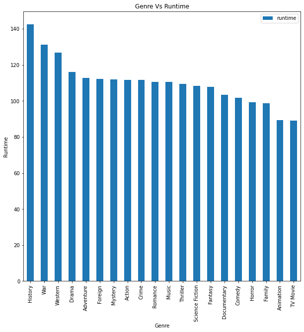

```python
runtime_df.plot('genre','runtime',kind='bar',figsize=(10,10))
plt.xlabel('Genre')
plt.ylabel('Runtime')
plt.title('Genre Vs Runtime');
```

### The longest movies are the history related movies followed by the war,western,drama.

## Limitations

Following are the limitations that I faced while working with the dataset :

```
1] The dataset is quite broader in terms of information and hence at times it becomes quite challenging to concentrate
on 1 insight at a time.

2] The dataset has 0 as value for important attributes.Neglecting this point can result into wrong insights.

3] The dataset has many null values as well which did not consume much time to rectify.

4] Identifying the attributes that could gives insights to our question and needs a thought.

5] These limitations are challenging but by overcoming them, I would acquire a problem solving ability.
```

## Conclusions

Following Conclusions can be derived from the above analysis : Q 1] For a movie to be successful and profitable, The revenue plays a very important role in getting the desired results. Although the Vote Ratings do not play a vital role in the success of a movie. The movie making business is more profitable in the recent years as compared to the earlier decades.

Q 2] A movie would have better chances of succeeding if it has one of the top 10 casts as derived in the question 2 analysis.

Q 4] The movie making business has had a huge growth in the last 2 decades and hence, the movie makers need to be more watchful for their competition as compared to the previous decades.

Q 5] The most profitable genres are derived in the analysis and it may be the basis for genre selection for the movie makers.

Q 6] The runtime of all the successful genres can be mapped to the average runtime and the movies can be edited around that average time.

```python
from subprocess import call
call(['python', '-m', 'nbconvert', 'Investigate_a_Dataset.ipynb'])
```

```
4294967295
```